# Documentation for the Market Snapshot Web Application

11/8/2021

## Overview

- The goal of the web application is to provide an overview of the US equity and bond market during a user defined time period.
- There are thee main components to the application:
  - The date range input located on the left side panel
  - The *Compare Indicators* tab that contians a plot showing each market indicator’s price over a given time frame
  - The *Price Prediction* tab that allows the user to select an indicator for price prediction
- Indicator price data from the FRED website.
  - [S&P 500](https://fred.stlouisfed.org/series/SP500)
  - [ICE BofA US Corporate Index Total Return Index Value](https://fred.stlouisfed.org/series/BAMLCC0A0CMTRIV)
  - [NASDAQ Composite Index](https://fred.stlouisfed.org/series/NASDAQCOM)

## Data Management

Due to US Stock Exchange holidays, the FRED data has a few observations for which the price is recorded as `.`

This is dealt with by imputing the missing price data with the previous day’s price. The code for this is shown below using the S&P 500 data and the `data.table` package. Once the price variable is imputed, we can make it numeric.

```r
sp1 <- sp[, imputed_price := fifelse(SP500 == '.', shift(SP500), SP500)]
sp[, imputed_price := as.numeric(imputed_price)]
sp[DATE %like% '12-24' | DATE %like% '12-25']
```

```
##          DATE   SP500 imputed_price
## 1: 2017-12-25       .       2683.34
## 2: 2018-12-24  2351.1       2351.10
## 3: 2018-12-25       .       2351.10
## 4: 2019-12-24 3223.38       3223.38
## 5: 2019-12-25       .       3223.38
## 6: 2020-12-24 3703.06       3703.06
## 7: 2020-12-25       .       3703.06
```

- The *Compare Indicators* tab also generates a table displaying the average price of each selected market indicator over the time period defined by the user. The general flow of the server code is as follows:
- Define a new, empty data table
- Iterate through the three indicators
  - If the indicator is selected, subset the indicator data according the date range chosen
  - Append indicator subset the data table defined in the first step
- With the data subsetted and combined appropriatly, use data table’s `by` argument to calculate the mean of each indicator’s price over the desired time period.

## Predictions

Similarly, the *Price Prediction* tab subsets the of the selected indicator using the date range defined by the user. Then, the plot and time series prediction is generated using the `forecast` package. This process is shown below:

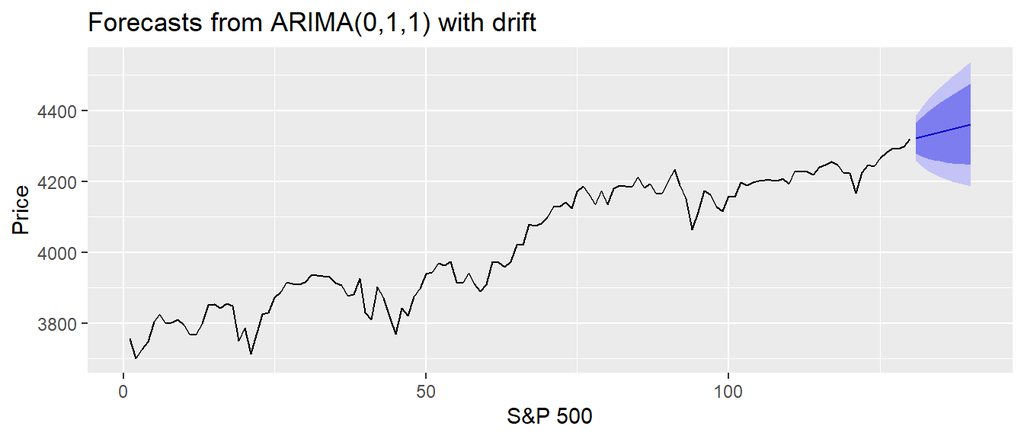

```r
subset <- sp[DATE %between% c('2021-01-01', '2021-07-01')]
subset$imputed_price %>%
  ts() %>%
  auto.arima() %>%
  forecast() %>%
  autoplot() + xlab('S&P 500') + ylab('Price')
```